# GDP Data Exploration

Mooyoung Lee

March 12, 2017

# Introduction

Data sets are provided, and the source of the files are same as followings.

- http://data.worldbank.org/data-catalog/GDP-ranking-table
- http://data.worldbank.org/data-catalog/ed-stats

Two data sets are cleaned and merged together. Data is explored and paid speciall attention to the GDP and Income Group relations.

## R-Version and Packages

```r
version
```

```
##                _
## platform       x86_64-w64-mingw32
## arch           x86_64
## os             mingw32
## system         x86_64, mingw32
## status
## major          3
## minor          3.2
## year           2016
## month          10
## day            31
## svn rev        71607
## language       R
## version.string R version 3.3.2 (2016-10-31)
## nickname       Sincere Pumpkin Patch
```

```r
packinfo <- installed.packages ()
packinfo[,c("Package","Version")]
```

```
##              Package        Version
## assertthat   "assertthat"   "0.1"
## backports    "backports"    "1.0.5"
## base64enc    "base64enc"    "0.1-3"
## BH           "BH"           "1.62.0-1"
## bitops       "bitops"       "1.0-6"
## caTools      "caTools"      "1.17.1"
## colorspace   "colorspace"   "1.3-2"
## crayon       "crayon"       "1.3.2"
## curl         "curl"         "2.3"
## data.table   "data.table"   "1.10.4"
## DBI          "DBI"          "0.5-1"
## devtools     "devtools"     "1.12.0"
## dichromat    "dichromat"    "2.0-0"
## digest       "digest"       "0.6.12"
## downloader   "downloader"   "0.4"
## dplyr        "dplyr"        "0.5.0"
## evaluate     "evaluate"     "0.10"
## fields       "fields"       "8.10"
## formatR      "formatR"      "1.4"
## gdata        "gdata"        "2.17.0"
## geosphere    "geosphere"    "1.5-5"
## ggmap        "ggmap"        "2.6.1"
## ggplot2      "ggplot2"      "2.2.1"
## git2r        "git2r"        "0.18.0"
## gtable       "gtable"       "0.2.0"
## gtools       "gtools"       "3.5.0"
## highr        "highr"        "0.6"
## htmltools    "htmltools"    "0.3.5"
## httr         "httr"         "1.2.1"
## jpeg         "jpeg"         "0.1-8"
## jsonlite     "jsonlite"     "1.3"
## knitr        "knitr"        "1.15.1"
## labeling     "labeling"     "0.3"
## lattice      "lattice"      "0.20-34"
## lazyeval     "lazyeval"     "0.2.0"
## magrittr     "magrittr"     "1.5"
## mapdata      "mapdata"      "2.2-6"
## mapproj      "mapproj"      "1.2-4"
## maps         "maps"         "3.1.1"
```

[output cut: 58 more lines]

```
## methods      "methods"      "3.3.2"
## mgcv         "mgcv"         "1.8-15"
## nlme         "nlme"         "3.1-128"
## nnet         "nnet"         "7.3-12"
## parallel     "parallel"     "3.3.2"
## rpart        "rpart"        "4.1-10"
## spatial      "spatial"      "7.3-11"
## splines      "splines"      "3.3.2"
## stats        "stats"        "3.3.2"
## stats4       "stats4"       "3.3.2"
## survival     "survival"     "2.39-5"
## tcltk        "tcltk"        "3.3.2"
## tools        "tools"        "3.3.2"
## translations "translations" "3.3.2"
## utils        "utils"        "3.3.2"
```

## Library Loading

A separate library list file is generated for better reproducibility.

```r
source("Analysis/Data/LibraryList.R")
```

### Library List includes:

- library(downloader)
- library(tidyr)
- library(ggplot2)
- library(mapdata)
- library(ggmap)
- library(RgoogleMaps)

## Data Importing

Two files are downloaded using a ‘download’ function.

```r
source("Analysis/Data/GDP_Importing.R")
```

## Data Importing Code (for grader)

```r
### GDP Case Study 1
### Data Importing
### Mooyoung Lee 3/11/2017

## Downloading GDP and Country detail information from an online source, which is given for this Case Study.

download("https://d396qusza40orc.cloudfront.net/getdata%2Fdata%2FGDP.csv", destfile = "gdp.csv")              # Download GDP data
download("https://d396qusza40orc.cloudfront.net/getdata%2Fdata%2FEDSTATS_Country.csv", destfile = "stat.csv") # Download country stats

gdp = read.csv("gdp.csv", sep = ",",stringsAsFactors = FALSE, header = FALSE)   # Open GDP file
stat = read.csv("stat.csv", sep = ",",stringsAsFactors = FALSE, header = TRUE)  # Open country stat file
```

## Data Cleaning

Two sets of data files are cleaned and merged. Some data types are changed.

```r
source("Analysis/Data/GDP_Cleaning.R")
```

## Data Cleaning Code (for grader)

```r
### GDP Case Study 1
### Data Cleaning
### Mooyoung Lee 3/11/2017

## Cleaning GDP table
gdpClean = gdp[, colSums(is.na(gdp)) != nrow(gdp)]                              # Delete columns with NA values only
colnames(gdpClean) = c("CountryCode", gdpClean[4,2:3], "GDPMilDollar", "Note")  # Assign column names
gdpNote = gdpClean[239:241,2]                                                   # Save the original NOTE on the bottom of the table in case
gdpClean = gdpClean[nchar(gdpClean[,1])>0,]                                     # Delete all emplty rows
gdpClean$GDPMilDollar = as.numeric(gsub(",","",gdpClean$GDPMilDollar))          # Save GDP values as numeric
gdpClean$Ranking = as.numeric(gdpClean$Ranking)                                 # Save Ranking values as numeric

## Merging data tables
gdpStat = merge(gdpClean, stat, by = intersect("CountryCode", "CountryCode"), all = TRUE) # Merge by contury code and sorting
gdpStatSort = gdpStat[order(gdpStat$GDPMilDollar),]                                       # Sort gdpStat table by GDP

## Manipulating tables in order to answer questions #3-#6
gdpStatSpread = spread(gdpStatSort, Income.Group, GDPMilDollar)                 # Spread GPD value into multiple Income group columns
gdpIncomeGather = gather(subset(gdpStatSpread, select =  c(35:39)),
                         "Income.Group", "GDPMilDollar", na.rm=TRUE)            # Gathering only useful Income Group data
gdpRankIncome = gdpStatSort[,c("Economy", "Ranking", "Income.Group")]           # Subset Ranking and Income group
gdpRankIncome = gdpRankIncome[!is.na(gdpRankIncome$Ranking),]                   # Select NA values from Ranking column
gdpRankIncome = gdpRankIncome[order(gdpRankIncome$Ranking),]                    # Sort ascending order
```

## Data Analysis

Explored the data by checking summary stats and distribution plots. Mapping tools are used to check the countries visually.

```r
source("Analysis/GDP_Analysis.R")
```

```
## [1] "ID Matching from Data Merging:  224"
## Countries that is matching(green) and not matching(red) from merging process (Figure below)
```

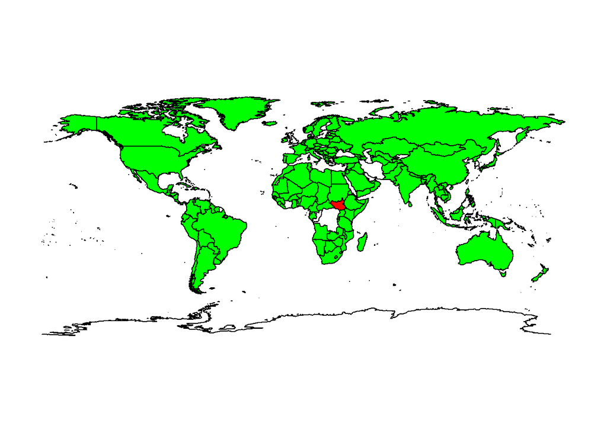

```
## [1] "13th Lowest GDP Country:  Grenada"
## [2] "13th Lowest GDP Country:  St. Kitts and Nevis"
## Countries within the 13th lowest GDP Ranking (Below Plot)
```

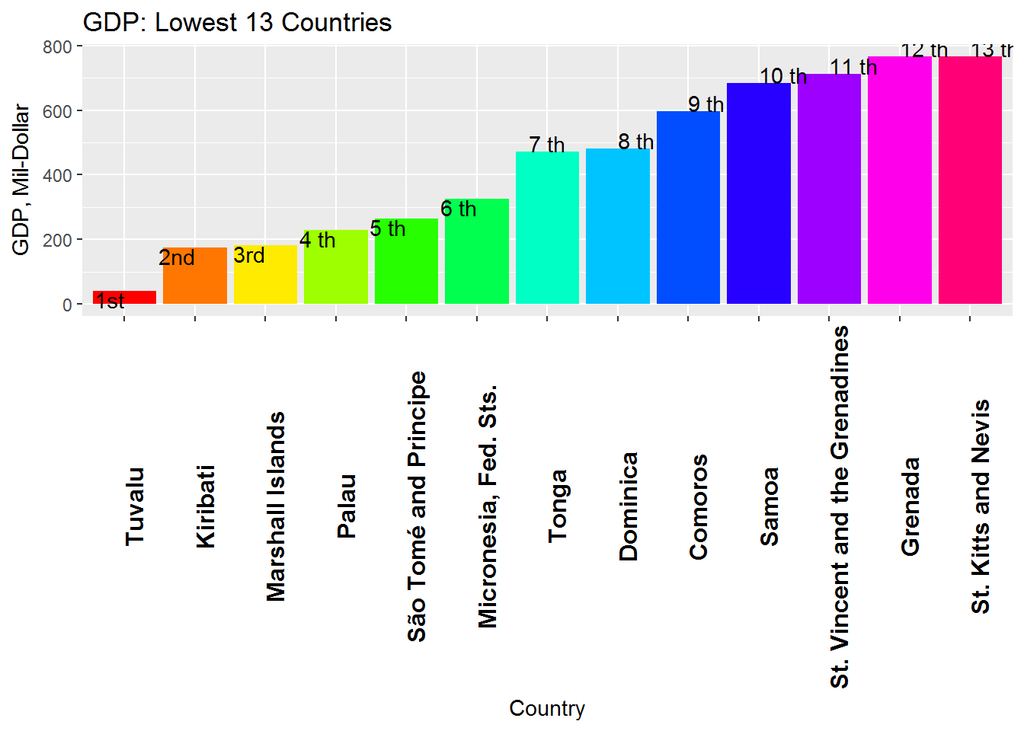

```
## Box Plot: GDP by Income Group
```

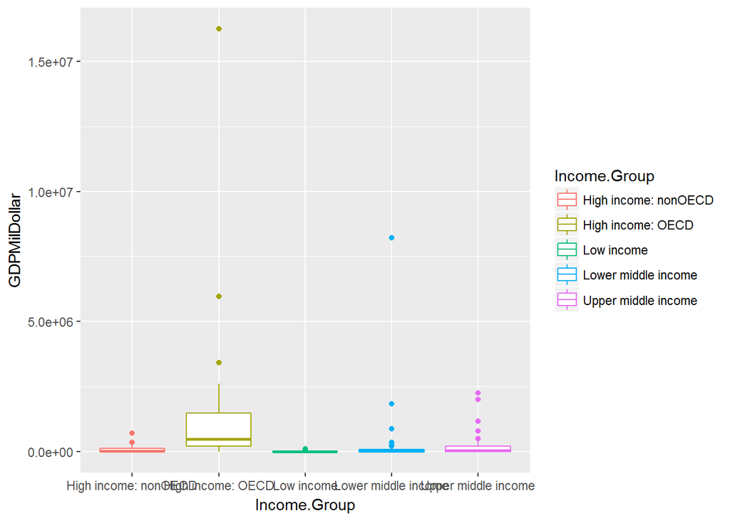

```
## Histogram: GDP by Income Group
```

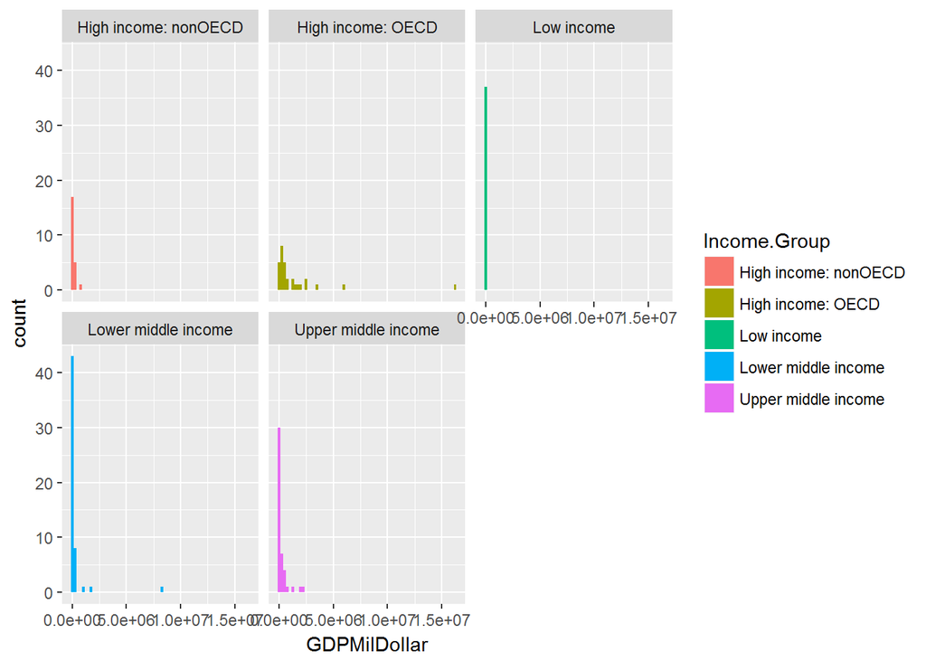

```
## GDP Summary Table
##  High income: nonOECD High income: OECD    Low income
##  Min.   :  2584       Min.   :   13579   Min.   :   596
##  1st Qu.: 12838       1st Qu.:  211147   1st Qu.:  3814
##  Median : 28373       Median :  486528   Median :  7843
##  Mean   :104350       Mean   : 1483917   Mean   : 14411
##  3rd Qu.:131205       3rd Qu.: 1480047   3rd Qu.: 17204
##  Max.   :711050       Max.   :16244600   Max.   :116355
##  NA's   :215          NA's   :208        NA's   :201
##  Lower middle income Upper middle income
##  Min.   :     40     Min.   :    228
##  1st Qu.:   2549     1st Qu.:   9613
##  Median :  24272     Median :  42945
##  Mean   : 256663     Mean   : 231848
##  3rd Qu.:  81448     3rd Qu.: 205789
##  Max.   :8227103     Max.   :2252664
##  NA's   :184         NA's   :193
## Total GDP by Income.Group
## High income: nonOECD    High income: OECD           Low income
##              2400046             44517514               533199
##  Lower middle income  Upper middle income
##             13859828             10433153
## Total GDP by Income.Group (RATIO)
## High income: nonOECD    High income: OECD           Low income
##          0.033453037          0.620507294          0.007431993
##  Lower middle income  Upper middle income
##          0.193185189          0.145422486
## GDP Ratio: U.S. vs. Rest OECD Countries
```

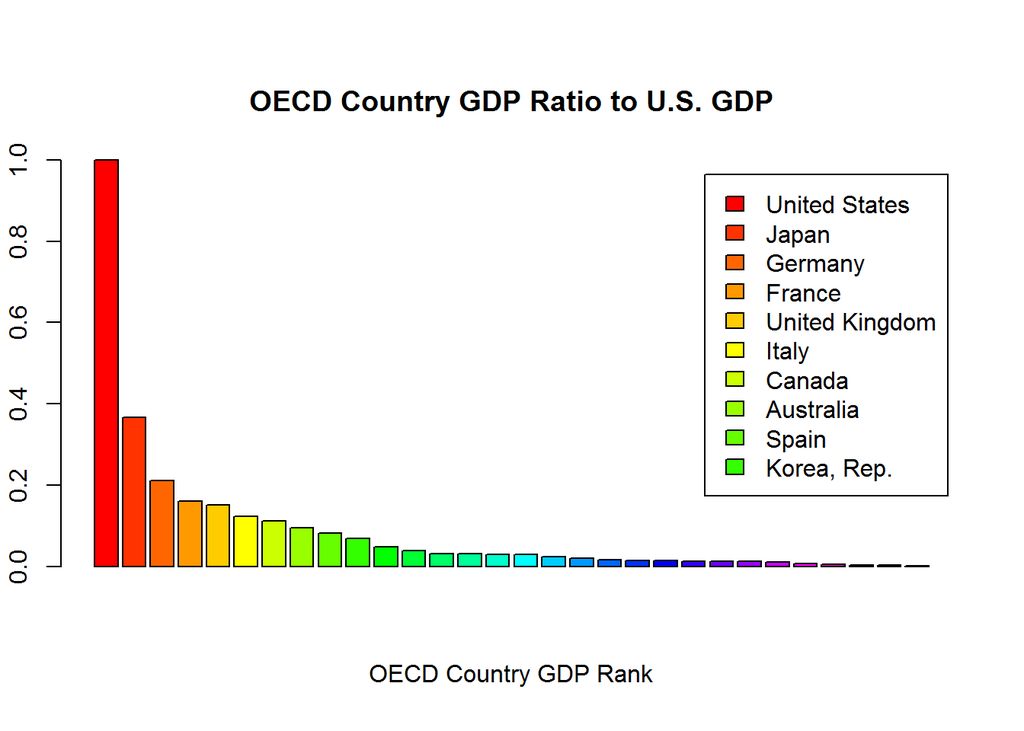

```
## GDP RAtio: U.S. GDP vs. All other OECD Country Total
## [1] 1.00000 1.74045
## GDP RAtio: U.S. GDP vs. All other Nations
## [1] 1.000000 3.416467
## Total Country Number by Income Group
## High income: nonOECD    High income: OECD           Low income
##                   23                   30                   37
##  Lower middle income  Upper middle income
##                   54                   45
## GDP Ranking: 5 Quantile Groups
## GDP Ranking Q1:
##                 Economy High income: nonOECD High income: OECD
## 1             Argentina                   NA                NA
## 2             Australia                   NA                12
## 3               Austria                   NA                27
```

[output cut: 408 more lines]

[figure not shown]

```
## Number of Countries in Lower middle income group and GDP Rank within 38th
## [1] 5
## Countries are in Lower middle income group and GDP Rank within 38th (Figure Below)
```

[figure not shown]

## Data Analysis Code (for grader)

```r
### GDP Case Study 1
### Data Analysis
### Mooyoung Lee 3/11/2017

## Question 1: How many of the IDs match?
q1_noIdMatch = sum(!is.na(match(gdpClean$CountryCode, stat$CountryCode)))       # Number of ID matching
print(paste("ID Matching from Data Merging: ", q1_noIdMatch))
# Country list that exist from both data files
CountryMatching = gdpClean[match(gdpClean$CountryCode, stat$CountryCode)>0,c("CountryCode","Economy")]
CountryMatching = na.omit(CountryMatching)

# Country list that are existing only on GDP data file
CountryNotMatchingGDP = gdpClean[is.na(match(gdpClean$CountryCode, stat$CountryCode)), c("CountryCode","Economy")]

# Country list that are existing only on STAT data file
CountryNotMatchingSTAT = stat[is.na(match(stat$CountryCode, gdpClean$CountryCode)), c("CountryCode","Long.Name")]

# Showing countries that is matching(green) and not matching(red) from merging process
cat("Countries that is matching(green) and not matching(red) from merging process (Figure below)\n")
map(resolution = 0)
map('world', regions=CountryMatching[,1], fill=TRUE, col='green', add = TRUE)
map('world', regions=CountryMatching[,2], fill=TRUE, col='green', add = TRUE)
# map('world', regions=CountryNotMatchingGDP[,1], fill=TRUE, col='red', add = TRUE)
map('world', regions=CountryNotMatchingGDP[,2], fill=TRUE, col='red', add = TRUE)
# map('world', regions=CountryNotMatchingSTAT[,1], fill=TRUE, col='orange', add = TRUE)
# map('world', regions=CountryNotMatchingSTAT[,2], fill=TRUE, col='orange', add = TRUE)

## Question 2: Waht is the 13th conuntry in the resulting data frame?
gdpRank = rank(gdpStatSort$Ranking, ties.method = c("average"))                                   # Rank the Ranking value
q2_13thLowGdp = gdpStatSort$Long.Name[gdpRank==gdpRank[13]]                                       # the 13th lowest GDP country; considered tie rank
print(paste("13th Lowest GDP Country: ", q2_13thLowGdp))

# Plotting the 13 lowest GDP countries
gdpStatSort2 = gdpStatSort[1:13,c("Economy", "GDPMilDollar")]
ggbar_13LowGDP = ggplot(gdpStatSort2, aes(x = factor(Economy, levels=unique(as.character(Economy))),
                         y = GDPMilDollar))+
                    geom_bar(stat = 'identity', fill = rainbow(13))+
                    xlab("Country")+
                    ylab("GDP, Mil-Dollar")+
                    theme(axis.text.x = element_text(face="bold", color="black",size=12, angle=90))+
                    ggtitle("GDP: Lowest 13 Countries")+
                    geom_text(aes(label = c("1st","2nd","3rd", paste(c(4:13),"th")), vjust = "outward", hjust = "outward"))
cat("Countries within the 13th lowest GDP Ranking (Below Plot)")
print(ggbar_13LowGDP)

## Question 3: Avg GDP rankings of "High income: OECD" and "High income: nonOECD" groups?
q3_avgRank.HiOecd = mean(gdpStatSpread$Ranking[gdpStatSpread$`High income: OECD`>0], na.rm=TRUE)                        # Avg GDP ranking of "High income: OECD"
q3_avgRank.HiNonOecd =mean(gdpStatSpread$Ranking[gdpStatSpread$`High income: nonOECD`>0], na.rm=TRUE)                   # Avg GDP ranking of "High income: OECD"
q3_avgRank = c(q3_avgRank.HiOecd, q3_avgRank.HiNonOecd)                                                                 # Group two answers together

## Question 4: Show distribution of GDP by income group
q4_box = ggplot(data = gdpIncomeGather, mapping = aes(x = Income.Group, y = GDPMilDollar, color =Income.Group ))+geom_boxplot()  # GDP Boxplot by Income Group

# q4_HistDodge = ggplot(data = gdpIncomeGather)+
#                     geom_histogram(mapping = aes(x = GDPMilDollar, fill = Income.Group),
#                                    binwidth = 100000, position = "dodge")             # GDP Histogram by Income Group

q4_HistIndiv = ggplot(data = gdpIncomeGather)+
                    geom_histogram(mapping = aes(x = GDPMilDollar, fill = Income.Group),
                                   binwidth = 250000, position = "dodge") +
                    facet_wrap(~ Income.Group, nrow = 2)                                                                                    # GDP Histogram by Income Group individually plotted

cat("Box Plot: GDP by Income Group\n")
print(q4_box)
cat("Histogram: GDP by Income Group\n")
print(q4_HistIndiv)

## Question 5: Summary Stats of GDP by income groups
q5_gdpSummary = summary(gdpStatSpread[,35:39])                                  # Summary Stat of GDP by income Groups
cat("********************************************************************************\n")
cat("GDP Summary Table\n")
cat("********************************************************************************\n")
print(q5_gdpSummary)

cat("Total GDP by Income.Group\n")
gdpTotal = colSums(gdpStatSpread[,35:39], na.rm = TRUE)
print(gdpTotal)
cat("Total GDP by Income.Group (RATIO)\n")
gdpTotalRatio = colSums(gdpStatSpread[,35:39], na.rm = TRUE)/sum(gdpStatSpread[,35:39], na.rm = TRUE)
print(gdpTotalRatio)
cat("GDP Ratio: U.S. vs. Rest OECD Countries\n")
countryOECD = na.omit(gdpStatSpread[,c("Economy","High income: OECD")])
countryOECD = countryOECD[order(countryOECD$`High income: OECD`, decreasing = TRUE),]
gdpOECDoverUS = countryOECD$`High income: OECD`/countryOECD[1,2]
barplot(gdpOECDoverUS, main = "OECD Country GDP Ratio to U.S. GDP",
        xlab = "OECD Country GDP Rank",
        col = rainbow(nrow(countryOECD)),
        legend = countryOECD$Economy[1:10])
cat("GDP RAtio: U.S. GDP vs. All other OECD Country Total\n")
print(c(1,sum(gdpOECDoverUS)-1))
cat("GDP RAtio: U.S. GDP vs. All other Nations\n")
print(c(countryOECD[1,2],sum(gdpStatSpread[,35:39], na.rm = TRUE)-countryOECD[1,2])/countryOECD[1,2])
noCountryGroup = colSums(!is.na(gdpStatSpread[,35:39]))
cat("Total Country Number by Income Group\n")
print(noCountryGroup)


## Question 6a: Spread GDP Ranking values into 5 quantile groups. Make a table versus Income.Group.
RIvector = c(1:nrow(gdpRankIncome))                                             # A vector has a same length as GDP table w/o NAs
RowSplit = split(RIvector, cut(RIvector, quantile(RIvector, probs = seq(0, 1, by = 0.2)),
                               include.lowest=TRUE))                            # Cut row numbers into 5 groups

for (i in 1:5){
                    assign(paste("RankQ",i, sep = ""), spread(gdpRankIncome[unlist(RowSplit[i]),],Income.Group, Ranking))
}                                                                               # Assign 5 quantile tables into RankQ1~5 tables.                                                                             # Copying Ranking values into corresponding Income groups;neat spreading

cat("********************************************************************************\n")
cat("GDP Ranking: 5 Quantile Groups\n")
cat("********************************************************************************\n")
cat("GDP Ranking Q1:\n")
print(RankQ1)
cat("GDP Ranking Q2:\n")
print(RankQ2)
cat("GDP Ranking Q3:\n")
print(RankQ3)
cat("GDP Ranking Q4:\n")
print(RankQ4)
cat("GDP Ranking Q5:\n")
print(RankQ5)

cat("GDP Summary for the First Quantile group\n")
q1Stat = summary(RankQ1)
print(q1Stat)

# High income: OECD Countries from each continent
oecdRegion = gdpStat[gdpStat$Income.Group=="High income: OECD", c("CountryCode","Economy","Region")]
oecdRegion = na.omit(oecdRegion)


## Selecting OECD countries in Europe and Plotting
oecdEurope = spread(oecdRegion, Region, CountryCode)
oecdEurope = na.omit(oecdEurope[,c(1,3)])


# getting the map
oecdEuropeCoord = geocode(oecdEurope[,1])                                       # Get coordinates of each country
df = oecdEuropeCoord                                                            # define data frame
map_oecdEurope <- get_map(location = c(lon = mean(df$lon), lat = mean(df$lat)), zoom = 3,
                      maptype = "roadmap", scale = 2)

# plotting the map with some points on it
MapEuropeOECD = ggmap(map_oecdEurope) +
                    geom_point(data = df, aes(x = lon, y = lat, fill = "red", alpha = 0.8), size = 5, shape = 21) +
                    guides(fill=FALSE, alpha=FALSE, size=FALSE)


cat("OECD countries in Europe (Figure Below)\n")
print(MapEuropeOECD)

## Question 6b: How many countries are in Lower middle income group but among the top 38 GDP nations?
q6_LMIRankAmong38 = sum(gdpStatSort$Ranking <= 38 & gdpStatSort$Income.Group =="Lower middle income", na.rm = TRUE)       # Number of countries among top 38 ranking
cat("Number of Countries in Lower middle income group and GDP Rank within 38th\n")
print(q6_LMIRankAmong38)

## Identifying the five countries from the above question
LowMidHigh38 = na.omit(gdpStat$Long.Name[gdpStat$Income.Group=="Lower middle income" & gdpStat$Ranking <=38])
# getting the map
df = geocode(LowMidHigh38)                                                      # Get coordinates of each country
map_LowMidGdpWithin38 = get_map(location = c(lon = mean(df$lon), lat = mean(df$lat)), zoom = 2,
                      maptype = "roadmap", scale = 2)

# plotting the map with some points on it
Map5countryQ6 = ggmap(map_LowMidGdpWithin38) +
                    geom_point(data = df, aes(x = lon, y = lat, fill = "red", alpha = 0.8), size = 5, shape = 21) +
                    guides(fill=FALSE, alpha=FALSE, size=FALSE)

cat("Countries are in Lower middle income group and GDP Rank within 38th (Figure Below)\n")
print(Map5countryQ6)
```

# Case Study Answers

Case study answers are grouped here.

```r
source("Analysis/Data/GDP_Answers.R")
```

```
## [1] "ID Matching:  224"
## [1] "13th Country:  Grenada"
## [2] "13th Country:  St. Kitts and Nevis"
## [1] "AVG Ranking (High OECD, High nonOECD) :  32.97 ,  91.91"
## Box Plot: GDP by Income Group
```

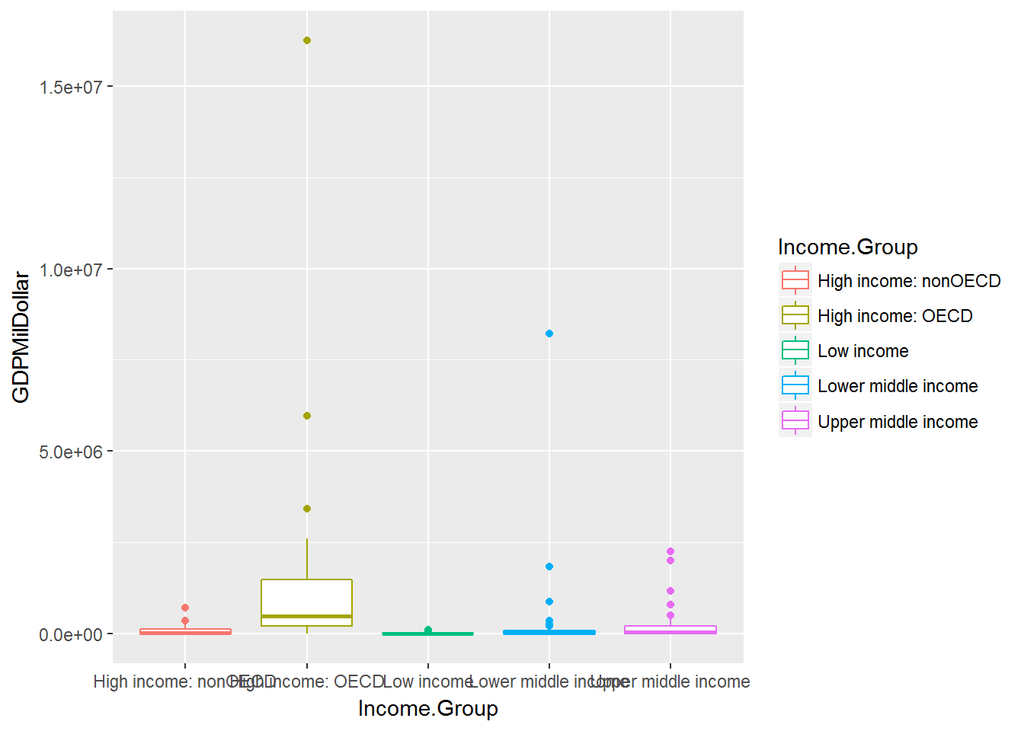

```
## Histogram: GDP by Income Group
```

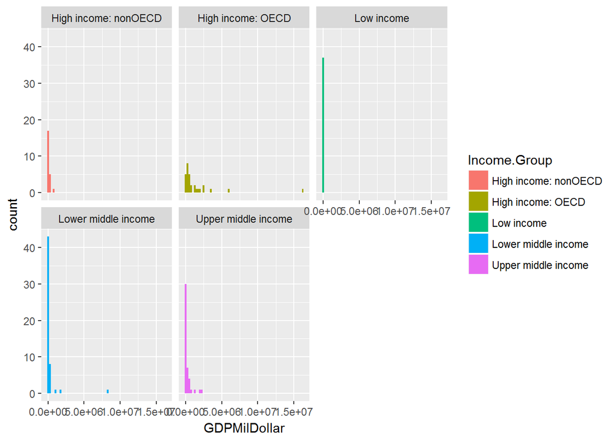

```
## GDP Summary Table
##  High income: nonOECD High income: OECD    Low income
##  Min.   :  2584       Min.   :   13579   Min.   :   596
##  1st Qu.: 12838       1st Qu.:  211147   1st Qu.:  3814
##  Median : 28373       Median :  486528   Median :  7843
##  Mean   :104350       Mean   : 1483917   Mean   : 14411
##  3rd Qu.:131205       3rd Qu.: 1480047   3rd Qu.: 17204
##  Max.   :711050       Max.   :16244600   Max.   :116355
##  NA's   :215          NA's   :208        NA's   :201
##  Lower middle income Upper middle income
##  Min.   :     40     Min.   :    228
##  1st Qu.:   2549     1st Qu.:   9613
##  Median :  24272     Median :  42945
##  Mean   : 256663     Mean   : 231848
##  3rd Qu.:  81448     3rd Qu.: 205789
```

[output cut: 400 more lines]

### Answers:

- 224 countries are matched using the country code when merging two files.
- The 13th country from the lowest GDP were “Grenada” and “St. Kitts and Nevis”. They are tied. Their average ranking is 178 (12.5th).
- The average GDP ranking for the “High income: OECD” group was 32.97.
- The average GDP ranking for the “High income: nonOECD” group was 91.91.
- Please see the above box plot and histograms to check the distribution of GDP by income group.
- The summary statistics of GDP by income groups are same as followings.

```
## GDP Summary Table
```

```
##  High income: nonOECD High income: OECD    Low income
##  Min.   :  2584       Min.   :   13579   Min.   :   596
##  1st Qu.: 12838       1st Qu.:  211147   1st Qu.:  3814
##  Median : 28373       Median :  486528   Median :  7843
##  Mean   :104350       Mean   : 1483917   Mean   : 14411
##  3rd Qu.:131205       3rd Qu.: 1480047   3rd Qu.: 17204
##  Max.   :711050       Max.   :16244600   Max.   :116355
##  NA's   :215          NA's   :208        NA's   :201
##  Lower middle income Upper middle income
##  Min.   :     40     Min.   :    228
##  1st Qu.:   2549     1st Qu.:   9613
##  Median :  24272     Median :  42945
##  Mean   : 256663     Mean   : 231848
##  3rd Qu.:  81448     3rd Qu.: 205789
##  Max.   :8227103     Max.   :2252664
##  NA's   :184         NA's   :193
```

- Please see the above 5 separate quantile groups for the GDP ranking from “RankQ1” ~ “RankQ”.
- There were 5 countries in the ‘Lower middle income’ group among the 38 nations with highest GDP.

## Conclusion

#### Technical:

- 224 counturies were matched when merging two sets of files from the world bank.
- The GDP rank for “Grenada” and “St. Kitts and Nevis” are tied.

#### Data Exploration:

- World Bank categorised the GDP income groups into five groups:

  ```
              * High income: nonOECD,
              * High income: OECD,
              * Low income,
              * Lower middle income,
              * Upper middle income.
  ```

- Summary statistics by each Income groups are same as below.

```
## GDP Summary Table
```

```
##  High income: nonOECD High income: OECD    Low income
##  Min.   :  2584       Min.   :   13579   Min.   :   596
##  1st Qu.: 12838       1st Qu.:  211147   1st Qu.:  3814
##  Median : 28373       Median :  486528   Median :  7843
##  Mean   :104350       Mean   : 1483917   Mean   : 14411
##  3rd Qu.:131205       3rd Qu.: 1480047   3rd Qu.: 17204
##  Max.   :711050       Max.   :16244600   Max.   :116355
##  NA's   :215          NA's   :208        NA's   :201
##  Lower middle income Upper middle income
##  Min.   :     40     Min.   :    228
##  1st Qu.:   2549     1st Qu.:   9613
##  Median :  24272     Median :  42945
##  Mean   : 256663     Mean   : 231848
##  3rd Qu.:  81448     3rd Qu.: 205789
##  Max.   :8227103     Max.   :2252664
##  NA's   :184         NA's   :193
```

```
## Total GDP by Income.Group
```

```
## High income: nonOECD    High income: OECD           Low income
##              2400046             44517514               533199
##  Lower middle income  Upper middle income
##             13859828             10433153
```

```
## Total GDP by Income.Group (RATIO)
```

```
## High income: nonOECD    High income: OECD           Low income
##          0.033453037          0.620507294          0.007431993
##  Lower middle income  Upper middle income
##          0.193185189          0.145422486
```

```
## Total Country Number by Income Group
```

```
## High income: nonOECD    High income: OECD           Low income
##                   23                   30                   37
##  Lower middle income  Upper middle income
##                   54                   45
```

- The GDP ratio of U.S. vs. the rest of OECD countries were 1 : 1.74.
- The GDP ratio of U.S. vs. the rest of world was 1 : 3.41.
- Distributions of each income groups followed right-skewed distribution. Low income group shows no tails since the GDP values were very little compared to other countries.
- Summary statistics for the top 38 GDP Ranking values are same as below:

```
## GDP Summary for the First Quantile group
```

```
##    Economy          High income: nonOECD High income: OECD
##  Length:38          Min.   :19.00        Min.   : 1.00
##  Class :character   1st Qu.:28.75        1st Qu.: 6.75
##  Mode  :character   Median :33.50        Median :14.00
##                     Mean   :30.75        Mean   :15.00
##                     3rd Qu.:35.50        3rd Qu.:22.50
##                     Max.   :37.00        Max.   :33.00
##                     NA's   :34           NA's   :20
##  Lower middle income Upper middle income
##  Min.   : 2.0        Min.   : 7.00
##  1st Qu.:10.0        1st Qu.:15.50
##  Median :16.0        Median :26.00
##  Mean   :19.4        Mean   :22.82
##  3rd Qu.:31.0        3rd Qu.:29.50
##  Max.   :38.0        Max.   :36.00
##  NA's   :33          NA's   :27
```

#### R-technical:

- map function from mapdata package do not find the countries well with using either country name or country code.
- get_map function from RgoogleMaps package have some limits on the query frequency per day.